# Bitcoin vs. Gold: Safe Haven Showdown (2015-2025)

Alexander G

2025-05-12

## Introduction

This project compares Bitcoin and gold as safe haven assets over a 10-year period (May 2015 to May 2025). I analyze their cumulative returns, volatility, and performance during market downturns to determine which asset is a better safe haven.

### Data Sources

*Bitcoin Prices: Sourced from Blockchain.com API (historical market price data).

*Gold Prices: Sourced from Alpha Vantage API using the GLD ETF (SPDR Gold Shares) as a proxy for gold prices.

*Data was cleaned in Google Sheets and processed in BigQuery to calculate weekly returns.

## Analysis

### Cumulative Returns

The plot below shows the cumulative returns of Bitcoin and gold over the 10-year period.

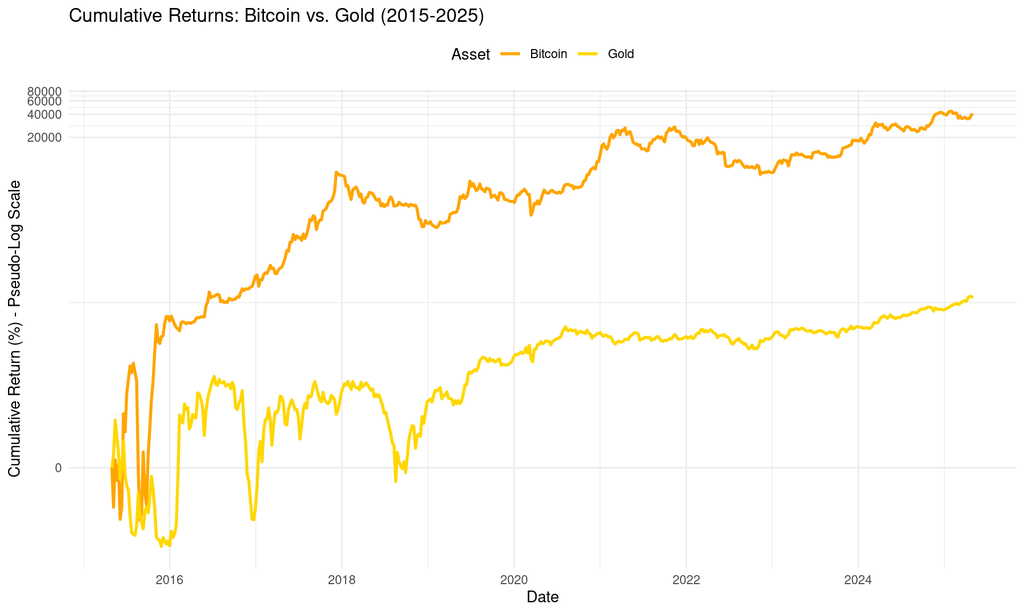

You can also explore an interactive version of this analysis in the [Tableau Dashboard](https://public.tableau.com/views/Bitcoinvs_GoldSafeHavenAnalysis2015-2025/BitcoinvsGoldDashboard?:language=en-US&:sid=&:redirect=auth&:display_count=n&:origin=viz_share_link).

### Key Metrics

```
## **Annualized Volatility**
```

```
## - Bitcoin: 0.73 %
```

```
## - Gold: 0.14 %
```

```
## **Average Return During Bitcoin Downturns (>10% Drop)**
```

```
## - Bitcoin: -16.61 %
```

```
## - Gold: -0.29 %
```

## Conclusion

*Cumulative Returns: Bitcoin likely outperformed gold significantly, but with higher volatility.

*Volatility: Gold exhibits lower volatility, making it a more stable asset.

*Safe Haven Performance: During Bitcoin downturns, gold typically performs better (e.g., positive or less negative returns), supporting its role as a safe haven.

*Recommendation: Gold appears to be the better safe haven due to its stability and performance during market stress, though Bitcoin may appeal to risk-tolerant investors seeking higher returns.